# Project 4 - Collaborative Filtering

Group 10

4/18/2018

## Table of Contents

Introduction  
Step 0: Load Packages & Specify Directories  
Step 1: Load and Process Data  
Step 2: Implement Algorithm  
Step 3: Evaluation

### Introduction

This project will examine two classes of collaborative filtering algorithms, i.e., the model-based algorithm (cluster model) and the memory-based algorithms. The algorithms will be evaluated for both the implicity and the explicity voting databases as follows:

- Data Set 1 [Microsoft Web Data](https://archive.ics.uci.edu/ml/datasets/Anonymous+Microsoft+Web+Data): an implicity dataset that captures individual visits to various areas in the Microsoft corporate website.
- Data Set 2 [EachMovie](http://www.gatsby.ucl.ac.uk/~chuwei/data/EachMovie/eachmovie.html), an explicity dataset that captures individual ratings ranged in value from 1 to 6 on various movies.

Note that 5,000 sampled users from the full data above will be used in this notebook to alleviate computation burden. In addition to implementing the memory-based algorithm (with Pearson or Spearman correlation, with and without variance weighting, and selecting neighbours) to both datasets, we will implement SimRank to Data Set 1 and the model-based algorithm (cluster model) to Data Set 2. To compare the predictive accuracy of the various methods, we will apply ranked scoring and mean absolute error (MAE) to Data Set 1 and Data Set 2 respectively.

### Step 0: Load Packages & Specify Directories

There are two packages used in this notebook, which are “reshape2” and “Hmisc”.

```r
# Packages that will be used
packages.used <- c("reshape2", "Hmisc")
# Check packages that need to be installed
packages.needed <- setdiff(packages.used,
                           intersect(installed.packages()[,1],
                                     packages.used))
# Install additional packages
if(length(packages.needed)>0){
  install.packages(packages.needed, dependencies = TRUE,
                   repos='http://cran.us.r-project.org')
}
# Load libraries
library("reshape2")
library("Hmisc")
# Set working directory to the doc folder
#setwd("~/GitHub/Spring2018-Project4-group-10/doc")
```

### Step 1: Load and Process Data

#### Load Data

This project is based on the following two datasets.

- Data Set 1: [Microsoft Web Data](https://archive.ics.uci.edu/ml/datasets/Anonymous+Microsoft+Web+Data)
- Data Set 2: [EachMovie](http://www.gatsby.ucl.ac.uk/~chuwei/data/EachMovie/eachmovie.html)

To alleviate computation burden, 5,000 sampled users from the full data above have been used in this notebook.

```r
train1 <- read.csv("../data/MS_sample/data_train.csv", header=TRUE)[-1]
test1 <- read.csv("../data/MS_sample/data_test.csv", header=TRUE)[-1]
train2 <- read.csv("../data/eachmovie_sample/data_train.csv", header=TRUE)
test2 <- read.csv("../data/eachmovie_sample/data_test.csv", header=TRUE)
```

#### Process Data

##### For Model-Based Algorithm (Cluster Models)

```r
#library("reshape2")
df.train2 <- dcast(train2, User~Movie, value.var = "Score", fill = NA)
df.test2 <- dcast(test2, User~Movie, value.var = "Score", fill = NA)
rownames(df.train2) <- df.train2[,1]
rownames(df.test2) <- df.test2[,1]
df.train2 <- df.train2[,-1]
df.test2 <- df.test2[,-1]
#df.train2[1:6,1:9]
```

##### For Memory-Based Algorithm

```r
source("../lib/Memory-based Model.R")
### transfer_1 -- transfer MS training data
### transfer_1_test -- transfer MS testing data to dataframe with columns of all websites
### transfer_2 -- transfer Movie data

run.transfer_1 <- FALSE
run.transfer_1_test <- FALSE
run.transfer_2 <- FALSE
if(run.transfer_1 & run.transfer_1_test & run.transfer_2){
  df_train1<-transfer_1(train1)
  df_test1<-transfer_1_test(test1,df_train1)
  df_train2<-transfer_2(train2)
  df_test2<-transfer_2(test2)
  save(df_train1, file = paste0("../output/df_train1.RData"))
  save(df_test1, file = paste0("../output/df_test1.RData"))
  save(df_train2, file = paste0("../output/df_train2.RData"))
  save(df_test2, file = paste0("../output/df_test2.RData"))
}else{
  load("../output/df_train1.RData")
  load("../output/df_test1.RData")
  load("../output/df_train2.RData")
  load("../output/df_test2.RData")
}
```

### Step 2: Implement Algorithm

#### Model-Based Algorithm (Cluster Models)

This section demonstrates how the cluster model have been implemented to the Data Set 2 (Each Movie). For details about this algorithm, pleae refer to [Notes on Cluster Model](https://github.com/TZstatsADS/ADS_Teaching/blob/master/Tutorials/wk12-notes_cluster/document.pdf) put together by Chengliang, Tang.

##### Stage

```r
# Set up controls
run.CM.cv <- FALSE
run.CM.pars <- FALSE
run.CM.est <- FALSE

# Source functions built
source("../lib/ClusterModel.R")
### cluster.cv -- Perfom K-Fold Cross-Validation
### cluster.em -- Learn Parameters Using EM Algorithm
### cluster.score -- Compute Score Estimation
### cluster.pi -- Compute Responsibilities
```

##### Choose C by 5-Fold Cross-Validation

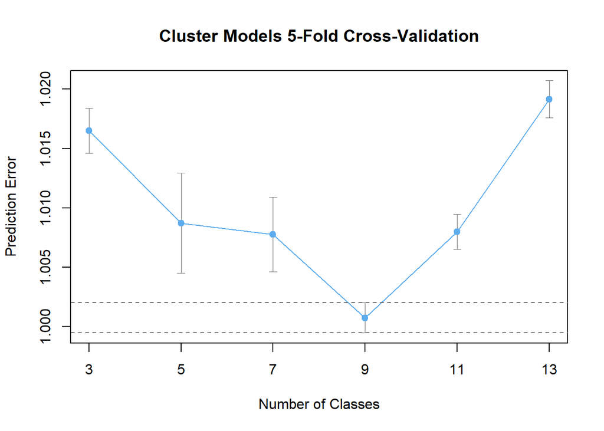

```r
# A set of C values to be tested
CM.C.list <- c(seq(3,13, by=2))

# Run 5-fold cross-validation
if(run.CM.cv){
  CM.error.validation <- cluster.cv(df.train2, CM.C.list)
  save(CM.error.validation, file = paste0("../output/CM.error.validation.RData"))
}else{
  load("../output/CM.error.validation.RData")
}

# Visualize results
#library("Hmisc")
CM.error.cv <- colMeans(CM.error.validation)
CM.error.cv.sd <- apply(CM.error.validation, 2, sd)/sqrt(nrow(CM.error.validation))
CM.c.min <- which.min(CM.error.cv)
CM.c.max <- which.max(CM.error.cv)
CM.error.cv.lbound <- CM.error.cv[CM.c.min] - CM.error.cv.sd[CM.c.min]
CM.error.cv.ubound <- CM.error.cv[CM.c.min] + CM.error.cv.sd[CM.c.min]
CM.error.cv.lylim <- min(CM.error.cv-CM.error.cv.sd)
CM.error.cv.uylim <- max(CM.error.cv+CM.error.cv.sd)
plot(CM.C.list, CM.error.cv, main = "Cluster Models 5-Fold Cross-Validation",
     xlab = "Number of Classes", ylab = "Prediction Error",
     ylim = c(CM.error.cv.lylim, CM.error.cv.uylim),
     xaxt = "n", type = "l", col="steelblue2")
axis(1, at = CM.C.list, labels = CM.C.list)
errbar(CM.C.list, CM.error.cv,
       CM.error.cv+CM.error.cv.sd, CM.error.cv-CM.error.cv.sd,
       add = TRUE, errbar.col = gray(0.4), lwd = 0.5)
points(CM.C.list, CM.error.cv, col="steelblue2",pch = 19)
abline(h=CM.error.cv.lbound, col=gray(0.4), lty=2)
abline(h=CM.error.cv.ubound, col=gray(0.4), lty=2)
```

```r
dev.copy2pdf(file ="../figs/CM.CrossValidation.pdf")
```

```r
CM.C.best <- CM.C.list[(CM.error.cv>CM.error.cv.lbound)
                       & (CM.error.cv<CM.error.cv.ubound)][1]
print(paste0("The best number of classes is ", CM.C.best, "."))
```

```
## [1] "The best number of classes is 9."
```

##### Learn Parameters with the C Chosen

```r
# Learn parameters with the C chosen
if(run.CM.pars){
  CM.pars <- cluster.em(df.train2, CM.C.best, 0.05)
  save(CM.pars, file = paste0("../output/CM.pars.RData"))
}else{
  load("../output/CM.pars.RData")
}
```

##### Compute Score Estimation & Test Error

```r
# Compute score estimation
if(run.CM.est){
  CM.est <- cluster.score(df.train2, CM.pars)
  save(CM.est, file = paste0("../output/CM.est.RData"))
}else{
  load("../output/CM.est.RData")
}

# Compute test error
CM.error.test <- sum(abs(CM.est-df.test2),na.rm = T)/ sum(!is.na(CM.est-df.test2))
print(paste0("The test error of the cluster model is ", round(CM.error.test,4),"."))
```

```
## [1] "The test error of the cluster model is 1.3603."
```

#### Memory-Based Algorithm

Based on user database which contains the history of users’ behaviours or preferance expressed by a set of votes $v_{i,j}$ corresponding to the vote for user i on item j, memory-based algorithm predicts the votes of the active users on items new to them based on a set of weights between users calculated from the user database. The memory-based algorithm have been implemented to both the implicit data (MS website), which is binary, showing that whether a user voted or not, and the explicit data (Each Movie), showing the scores. By using default voting, we first have used different methods to calculate correlations between users (pearson, spearman, pearson+variance weight, SimRank), and then defined a set of neighbors which have specific correlations with an active user by setting weight thresholds. For prediction, the predicted scores have been assigned to the items that the users have never voted before. For evaluation, we have used expected utility of a ranked list of items to show how users are satisfied with the recommendation for the implicit data and MAE to get the accuracy for the explicit data. Besides using different methods to calculate correlation, different thresholds, which would show different coverage, and different ways of calculating predicted scores (scaled or not) have also been considered in the memory-based algorithm.

##### Stage

```r
run.simweight <- FALSE
run.rmna <-FALSE
run.var_weight <- FALSE
run.simrank <- FALSE
run.pred_1 <- FALSE
run.pred_2 <- FALSE
run.rank_score <-FALSE
run.get_neighbors_index<- FALSE


### simweight --  similarity weight
### rmna --
### var_weight -- variance weight
### simrank -- simrank weight
### get_neighbors_index -- Neighbors selection by weight threshold
### pred_1 -- Produce a prediction score matrix for dataset MS(implicit)
### pred_2 -- Produce a prediction score matrix for dataset Movie(explicit)
### rank_score -- Evaluation for implicit dataset: expected utility of ranked list
```

##### Compute Weight Matrix and Select Neighbors by Threshold

Matrix and Select Neighbors by Threshold Here, we use pearson correlation, spearman correlation, simrank weighting to calculate similarity weighting. Then we also add variance weighting into pearson correlation. We also conduct weight threshold to select neighbours to improve accuracy and efficiency of our model.

```r
if(run.simweight & run.var_weight & run.simrank & run.get_neighbors_index){
  # calculate similarity weight by different methods
  weight_pearson_1<-simweight(df_train1,"pearson")
  weight_spearman_1<-simweight(df_train1,"spearman")
  weight_pearson_2_temp<-simweight(df_train2,"pearson")
  weight_pearson_2<-rmna(weight_pearson_2_temp,df_train2)
  weight_spearman_2_temp<-simweight(df_train2,"spearman")
  weight_spearman_2<-rmna(weight_spearman_2_temp,df_train2)
  save(weight_pearson_1, file = paste0("../output/weight_pearson_1.RData"))
  save(weight_spearman_1, file = paste0("../output/weight_spearman_1.RData"))
  save(weight_pearson_2, file = paste0("../output/weight_pearson_2RData"))
  save(weight_spearman_2, file = paste0("../output/weight_spearman_2.RData"))

  # calculate variance weight combined with pearson similarity weight
  weight_var_pear_1<-var_weight(df_train1,"pearson")
  weight_var_pear_2<-var_weight(df_train2,"pearson")
  save(weight_var_pear_1, file = paste0("../output/weight_var_pear_1.RData"))
  save(weight_var_pear_2, file = paste0("../output/weight_var_pear_2.RData"))

  # calculate SimRank
  weight_simrank_1<-simrank(df_train1)
  save(weight_simrank_1, file = paste0("../output/weight_simrank_1.RData"))

  # select each user's neighbors index from weight matrix by different threshold
  k<-c(-10,0.2,0.3,0.4,0.5)
  neighbors_pearson_1<-c()
  neighbors_spearman_1<-c()
  neighbors_var_pear_1<-c()
  neighbors_pearson_2<-c()
  neighbors_spearman_2<-c()
  neighbors_var_pear_2<-c()
  for(i in 1:5){
    neighbors_pearson_1[[i]]<-get_neighbors_index(weight_pearson_1,k[i])
    neighbors_spearman_1[[i]]<-get_neighbors_index(weight_spearman_1,k[i])
    neighbors_var_pear_1[[i]]<-get_neighbors_index(weight_var_pear_1,k[i])
    neighbors_pearson_2[[i]]<-get_neighbors_index(weight_pearson_2,k[i])
    neighbors_spearman_2[[i]]<-get_neighbors_index(weight_spearman_2,k[i])
    neighbors_var_pear_2[[i]]<-get_neighbors_index(weight_var_pear_2,k[i])
    }
  neighbors_simrank_1<-get_neighbors_index(weight_simrank_1,0)
  save(neighbors_pearson_1, file = paste0("../output/neighbors_pearson_1.RData"))
  save(neighbors_spearman_1, file = paste0("../output/neighbors_spearman_1.RData"))
  save(neighbors_var_pear_1, file = paste0("../output/neighbors_var_pear_1.RData"))
  save(neighbors_pearson_2, file = paste0("../output/neighbors_pearson_2.RData"))
  save(neighbors_spearman_2, file = paste0("../output/neighbors_spearman_2.RData"))
  save(neighbors_simrank_1, file = paste0("../output/neighbors_simrank_1.RData"))

  load("../output/weight_pearson_1.RData")
  load("../output/weight_spearman_1.RData")
  load("../output/weight_pearson_2.RData")
  load("../output/weight_spearman_2.RData")
  load("../output/weight_var_pear_1.RData")
  load("../output/weight_var_pear_2.RData")
  load("../output/weight_simrank_1.RData")

  load("../output/neighbors_pearson_1.RData")
  load("../output/neighbors_spearman_1.RData")
  load("../output/neighbors_pearson_2.RData")
  load("../output/neighbors_spearman_2.RData")
  load("../output/neighbors_var_pear_1.RData")
  load("../output/neighbors_var_pear_2.RData")
  load("../output/neighbors_simrank_1.RData")
}
```

##### Calculate Prediction Score and Evaluate Ranked List

```r
# predict vote by using scaled/non_scaled z-score
if(run.pred_1 & run.rank_score){
  pearson_score<-c()
  spearman_score<-c()
  var_pear_score<-c()
  pearson_score_noweighted<-c()
  spearman_score_noweighted<-c()
  var_pear_score_noweighted<-c()
  for(i in 1:5){
    pred_pearson_1<-pred_1(df_train1,df_test1,weight_pearson_1,neighbors_pearson_1[[i]]$top.neighbors)
    pred_spearman_1<-pred_1(df_train1,df_test1,weight_spearman_1,neighbors_spearman_1[[i]]$top.neighbors)
    pred_var_pear_1<-pred_1(df_train1,df_test1,weight_var_pear_1,neighbors_var_pear_1[[i]]$top.neighbors)
    pearson_score[i]<-rank_score(pred_pearson_1,df_test1)
    spearman_score[i]<-rank_score(pred_spearman_1,df_test1)
    var_pear_score[i]<-rank_score(pred_var_pear_1,df_test1)
    pred_pearson_1_noweighted<-pred_1_NoWeightedAverage(df_train1,df_test1,weight_pearson_1,neighbors_pearson_1[[i]]$top.neighbors)
    pred_spearman_1_noweighted<-pred_1_NoWeightedAverage(df_train1,df_test1,weight_spearman_1,neighbors_spearman_1[[i]]$top.neighbors)
    pred_var_pear_1_noweighted<-pred_1_NoWeightedAverage(df_train1,df_test1,weight_var_pear_1,neighbors_var_pear_1[[i]]$top.neighbors)
    pearson_score_noweighted[i]<-rank_score(pred_pearson_1_noweighted,df_test1)
    spearman_score_noweighted[i]<-rank_score(pred_spearman_1_noweighted,df_test1)
    var_pear_score_noweighted[i]<-rank_score(pred_var_pear_1_noweighted,df_test1)
}
  pred_simrank_1<-pred_1(df_train1,df_test1,weight_simrank_1,neighbors_simrank_1$top.neighbors)
  simrank_score<-rank_score(pred_simrank_1,df_test1)
  pred_simrank_1_noweighted<-pred_1_NoWeightedAverage(df_train1,df_test1,weight_simrank_1,neighbors_simrank_1$top.neighbors)
  simrank_score_noweighted<-rank_score(pred_simrank_1_noweighted,df_test1)

  save(pearson_score, file = paste0("../output/pearson_score.RData"))
  save(spearman_score, file = paste0("../output/spearman_score.RData"))
  save(var_pear_score, file = paste0("../output/var_pear_score.RData"))
  save(simrank_score, file = paste0("../output/simrank_score.RData"))
  save(pearson_score_noweighted, file = paste0("../output/pearson_score_noweighted.RData"))
  save(spearman_score_noweighted, file = paste0("../output/spearman_score_noweighted.RData"))
  save(var_pear_score_noweighted, file = paste0("../output/var_pear_score_noweighted.RData"))
  save(simrank_score_noweighted, file = paste0("../output/simrank_score_noweighted.RData"))
}
  load("../output/pearson_score.RData")
  load("../output/spearman_score.RData")
  load("../output/var_pear_score.RData")
  load("../output/simrank_score.RData")
  load("../output/pearson_score_noweighted.RData")
  load("../output/spearman_score_noweighted.RData")
  load("../output/var_pear_score_noweighted.RData")
  load("../output/simrank_score_noweighted.RData")
```

```r
#for(i in 1:4){
  #temp1<-weight_pearson_2
  #temp1[temp1>k[i]]<-0
  #temp2<-weight_spearman_2
  #temp2[temp2>k[i]]<-0
  #temp3<-weight_var_pear_2
  #temp3[temp3>k[i]]<-0
  # pred_pearson_2[i]<-pred_2(df_train2,df_test2,temp1)
  # pred_spearman_2[i]<-pred_2(df_train2,df_test2,temp2)
  # pred_var_2[i]<-pred_2(df_train2,df_test2,temp3)
#}
```

### Step 3: Evaluation

There are two evaluation methods we used. We used Ranked Scoring to evaluate dataset1, which is implicit data. The higher the Ranked Scoring, the better the result. And we use MAE to evaluate dataset2, which is explicit data. The lower the mae, the better the result. Here are the algorithm functions for these two evaluation methods.

#### Rank Scoring function for datset1

```r
rank_score <- function(predict,test){
  ## function to calculate rank score of predicted value
  ## input: predict - predicted value matrix of test data
  ##        test - test data matrix
  ## output: rank score
  d <- 0
  alpha<-10
  #predict<-predict[rownames(predict)%in%rownames(test),]#colnames(predict)%in%colnames(test)
  rank_mat_pred <- ncol(predict)+1-t(apply(predict,1,function(x){return(rank(x,ties.method = 'first'))}))
  rank_mat_test <- ncol(test)+1-t(apply(test,1,function(x){return(rank(x,ties.method = 'first'))}))
  #vec_pred <- ifelse(predict - d > 0, predict - d, 0)
  vec_test <- ifelse(test - d > 0, test - d, 0)
  R_a <- apply(1/(2^((rank_mat_pred-1)/(alpha-1))) * vec_test,1,sum)
  R_a_max <- apply(1/(2^((rank_mat_test-1)/(alpha-1))) * vec_test,1,sum)
  R <- 100*sum(R_a)/sum(R_a_max)
  return(R)
}
```

#### MAE function for dataset2

```r
MAE <- function(predict,test){
  ## function to calculate mean absolute error of predicted value
  ## Input: predict - predicted value
  ##        test - test data matrix
  ## Output: MAE
  mae <- mean(abs(predict-test),na.rm=T)
  return(mae)
}
```

#### Results and conclusion for dataset1

```r
source("../lib/table_function.R")
#Dataset1
result(dataname=1,weighted=T)
```

```
##   weight.thershold pearson.var.off spearman.var.off pearson.var.on simrank
## 1              0.0              NA               NA             NA 40.7706
## 2              0.2         39.3642          39.3642        39.9775      NA
## 3              0.3         38.0771          38.0771        39.1456      NA
## 4              0.4          5.8205           5.8205        38.0915      NA
## 5              0.5          1.8353           1.8375         5.8566      NA
```

```r
result(dataname=1,weighted=F)
```

```
##   weight.thershold pearson.var.off spearman.var.off pearson.var.on simrank
## 1              0.0              NA               NA             NA 40.7763
## 2              0.2         39.4591          39.4591        39.9600      NA
## 3              0.3         38.1718          38.1718        39.2331      NA
## 4              0.4          5.8577           5.8577        38.2328      NA
## 5              0.5          1.8487           1.8463         5.8711      NA
```

From the form, the simrank’s ranked score is higher which means the Simrank correlation is better than other correlation.As we can see from our result, when the coverage of neigbours is lower than 20%, the prediction will become worse.

#### Results and conclusion for dataset2

```r
#Dataset2
##Memory-based Model
result(dataname=2,weighted=T)
```

```
##   weight.thershold pearson.var.off spearman.var.off pearson.var.on
## 1              0.0          1.4285           1.5938         1.8833
## 2              0.2          1.1374           1.1379         1.1457
## 3              0.3          1.1474           1.1497         1.1591
## 4              0.4          1.1664           1.1715         1.1822
## 5              0.5          1.2029           1.2107         1.2167
```

```r
result(dataname=2,weighted=F)
```

```
##   weight.thershold pearson.var.off spearman.var.off pearson.var.on
## 1              0.0          1.3369           1.3194         1.6937
## 2              0.2          1.1357           1.1360         1.1400
## 3              0.3          1.1406           1.1422         1.1406
## 4              0.4          1.1497           1.1532         1.1497
## 5              0.5          1.1696           1.1749         1.1696
```

```r
##Compare with Cluster Model
load("../output/prednowei_pear_thres0.2.RData")
data.frame(Method=c("Cluster Model","Memory-Based Model ( Corrleation = Pearson Variance = No Threshold =0.2)"),MAE=c(CM.error.test,prednowei_pear_thres0.2))
```

```
##                                                                     Method
## 1                                                            Cluster Model
## 2 Memory-Based Model ( Corrleation = Pearson Variance = No Threshold =0.2)
##        MAE
## 1 1.360271
## 2 1.135716
```

For data2, the Memory-Based Model (pearson correlation, threshold=0.2) is better than the Cluster Model.

Variance Weighting improves the performance for data1, while lowers the performance for data2. The best threshold is 0.2 for both data sets.